# The Role of Attachment Style in Perceived Romantic Attractiveness and Relationship Expectations: Effects of High vs. Low Communication in Dating Profiles

- Show All Code
- Hide All Code
- View Source

PSY 120L Reproducible Analysis Report

Author

Simran Patel

Published

May 25, 2026

## About This Report

This reproducible report presents the analyses conducted for our final research project examining how communication style displayed in a dating profile (high vs. low communication) and attachment anxiety (high vs. low attachment anxiety) influence perceptions of social attraction and relationship expectations. The report documents the data preparation, variable preparation, descriptive statistics, primary analyses, and figures for this study. This report is intended to go with a research paper, and is not the full paper itself. The report shows how the reported analyses were produced from the dataset using a transparent and reproducible Quarto workflow.

## Study Overview

This study examined whether communication style displayed in a dating profile (high communication vs. low communication) influenced perceptions of social attraction and relationship expectations, with Attachment Anxiety (high vs. low) as a potential moderator. The primary analyses tested whether Communication, Attachment Anxiety, and their interaction predicted each outcome.

## Setup and Software Environment

This section loads the packages used for data preparation, scale construction, statistical modeling, estimated marginal means, and figures.

**Load Packages**

```r
library(tidyverse)  # data manipulation + plotting
library(psych)      # scale construction + reliability
library(afex)       # ANOVA models + effect sizes
library(emmeans)    # estimated marginal means + confidence intervals
```

## Data Source and Analysis Dataset

The dataset was imported from the project data folder. The imported dataset was saved as study_raw so that the original file remained unchanged throughout the report.

A smaller analysis dataset was then created for the current analyses. This dataset retained the experimental condition variable (communication style), attachment anxiety scores, demographic variables, and the outcome measures of social attraction and relationship expectations needed for variable preparation and analysis.

### Import Dataset

```r
study_raw <- read_csv("data/relationship_preferences_data.csv")
```

### Check Imported Dataset

```r
dim(study_raw)
```

```
[1] 95 66
```

```r
names(study_raw)
```

```
 [1] "StartDate"             "EndDate"               "Status"
 [4] "IPAddress"             "Progress"              "Duration (in seconds)"
 [7] "Finished"              "RecordedDate"          "ResponseId"
[10] "ExternalReference"     "LocationLatitude"      "LocationLongitude"
[13] "DistributionChannel"   "UserLanguage"          "Q1"
[16] "ETTR_1"                "ETTR_2"                "ETTR_3"
[19] "ETTR_4"                "ETTR_5"                "ETTR_6"
[22] "ETTR_7"                "ETTR_8"                "ETTR_9"
[25] "ETTR_10"               "ETTR_11"               "ETTR_12"
[28] "ETTR_13"               "ETTR_14"               "ETTR_15"
[31] "ETTR_16"               "ETTR_17"               "ETTR_18"
[34] "ETTR_19"               "IAS_1"                 "IAS_2"
[37] "IAS_3"                 "IAS_4"                 "IAS_5"
[40] "IAS_6"                 "IAS_7"                 "IAS_8"
[43] "IAS_9"                 "IAS_10"                "AAS_1"
[46] "AAS_2"                 "AAS_3"                 "AAS_4"
[49] "AAS_5"                 "AAS_6"                 "AAS_7"
[52] "AAS_8"                 "AAS_9"                 "AAS_10"
[55] "AAS_11"                "AAS_12"                "AAS_13"
[58] "AAS_14"                "AAS_15"                "AAS_16"
[61] "AAS_17"                "AAS_18"                "age"
[64] "gender"                "relationship"          "condition"
```

```r
head(study_raw)
```

```
# A tibble: 6 × 66
  StartDate    EndDate Status IPAddress Progress Duration (in seconds…¹ Finished
  <chr>        <chr>    <dbl> <chr>        <dbl>                  <dbl>    <dbl>
1 5/5/26 18:58 5/5/26…      0 68.6.116…      100                    261        1
2 5/5/26 19:03 5/5/26…      0 172.226.…      100                    416        1
3 5/5/26 19:10 5/5/26…      0 76.183.1…      100                    527        1
4 5/5/26 19:50 5/5/26…      0 172.58.1…      100                    327        1
5 5/5/26 19:52 5/5/26…      0 184.187.…      100                    291        1
6 5/5/26 19:50 5/5/26…      0 71.195.1…      100                    575        1
# ℹ abbreviated name: ¹`Duration (in seconds)`
# ℹ 59 more variables: RecordedDate <chr>, ResponseId <chr>,
#   ExternalReference <lgl>, LocationLatitude <dbl>, LocationLongitude <dbl>,
#   DistributionChannel <chr>, UserLanguage <chr>, Q1 <dbl>, ETTR_1 <dbl>,
#   ETTR_2 <dbl>, ETTR_3 <dbl>, ETTR_4 <dbl>, ETTR_5 <dbl>, ETTR_6 <dbl>,
#   ETTR_7 <dbl>, ETTR_8 <dbl>, ETTR_9 <dbl>, ETTR_10 <dbl>, ETTR_11 <dbl>,
#   ETTR_12 <dbl>, ETTR_13 <dbl>, ETTR_14 <dbl>, ETTR_15 <dbl>, …
```

### Create Analysis Dataset

```r
study_vars <- c(

      "condition",
      "age", "gender", "relationship",

      "IAS_1","IAS_2","IAS_3","IAS_4", "IAS_5","IAS_6",
      "IAS_7","IAS_8","IAS_9","IAS_10",

      "AAS_1","AAS_2","AAS_3","AAS_4","AAS_5","AAS_6","AAS_7",
      "AAS_8","AAS_9","AAS_10","AAS_11","AAS_12", "AAS_13","AAS_14",
      "AAS_15","AAS_16","AAS_17","AAS_18",

      "ETTR_1", "ETTR_2", "ETTR_3", "ETTR_4", "ETTR_5", "ETTR_6",
      "ETTR_7", "ETTR_8", "ETTR_9", "ETTR_10", "ETTR_11", "ETTR_12",
      "ETTR_13", "ETTR_14", "ETTR_15", "ETTR_16", "ETTR_17", "ETTR_18",
      "ETTR_19"
)


study_data <- study_raw %>%
  select(all_of(study_vars)) %>%
  mutate(across(everything(), as.numeric))
```

### Check Analysis Dataset

```r
length(study_vars)
```

```
[1] 51
```

```r
dim(study_data)
```

```
[1] 95 51
```

```r
names(study_data)
```

```
 [1] "condition"    "age"          "gender"       "relationship" "IAS_1"
 [6] "IAS_2"        "IAS_3"        "IAS_4"        "IAS_5"        "IAS_6"
[11] "IAS_7"        "IAS_8"        "IAS_9"        "IAS_10"       "AAS_1"
[16] "AAS_2"        "AAS_3"        "AAS_4"        "AAS_5"        "AAS_6"
[21] "AAS_7"        "AAS_8"        "AAS_9"        "AAS_10"       "AAS_11"
[26] "AAS_12"       "AAS_13"       "AAS_14"       "AAS_15"       "AAS_16"
[31] "AAS_17"       "AAS_18"       "ETTR_1"       "ETTR_2"       "ETTR_3"
[36] "ETTR_4"       "ETTR_5"       "ETTR_6"       "ETTR_7"       "ETTR_8"
[41] "ETTR_9"       "ETTR_10"      "ETTR_11"      "ETTR_12"      "ETTR_13"
[46] "ETTR_14"      "ETTR_15"      "ETTR_16"      "ETTR_17"      "ETTR_18"
[51] "ETTR_19"
```

The analysis dataset contains the variables required for the report. The checks confirm the number of selected variables, the dimensions of the analysis dataset, and the final variable names carried forward into the preparation and analysis sections.

## Variable Preparation

This section prepares the variables used in the primary analyses. The original imported dataset was left unchanged; all prepared variables were created in the working analysis dataset, study_data.

### Prepare Participant ID and Experimental Condition

```r
study_data <- study_data %>%
  mutate(
    id = row_number(),
    condition = factor(
      condition,
      levels = c(0, 1),
      labels = c("Low", "High")
    )
  )
```

The communication condition variable was recoded as a labeled factor with two levels: Low Communication and High Communication. A participant ID variable was also created so that each row in the analysis dataset had a unique identifier.

### Check Experimental Condition Coding

```r
study_data %>%
  count(condition) %>%
  knitr::kable(
    col.names = c("Condition", "n")
  )
```

| Condition | n |
| --- | --- |
| Low | 45 |
| High | 50 |

The condition check confirms the number of participants assigned to each communication condition (Low Communication vs. High Communication).

### Check Prepared Analysis Dataset

```r
dim(study_data)
```

```
[1] 95 52
```

```r
names(study_data)
```

```
 [1] "condition"    "age"          "gender"       "relationship" "IAS_1"
 [6] "IAS_2"        "IAS_3"        "IAS_4"        "IAS_5"        "IAS_6"
[11] "IAS_7"        "IAS_8"        "IAS_9"        "IAS_10"       "AAS_1"
[16] "AAS_2"        "AAS_3"        "AAS_4"        "AAS_5"        "AAS_6"
[21] "AAS_7"        "AAS_8"        "AAS_9"        "AAS_10"       "AAS_11"
[26] "AAS_12"       "AAS_13"       "AAS_14"       "AAS_15"       "AAS_16"
[31] "AAS_17"       "AAS_18"       "ETTR_1"       "ETTR_2"       "ETTR_3"
[36] "ETTR_4"       "ETTR_5"       "ETTR_6"       "ETTR_7"       "ETTR_8"
[41] "ETTR_9"       "ETTR_10"      "ETTR_11"      "ETTR_12"      "ETTR_13"
[46] "ETTR_14"      "ETTR_15"      "ETTR_16"      "ETTR_17"      "ETTR_18"
[51] "ETTR_19"      "id"
```

The prepared analysis dataset contains the variables needed for scale construction, descriptive statistics, and primary analyses, including communication condition, attachment anxiety, social attraction, and relationship expectations.

### Reverse-Code Scale Items

Items requiring reverse coding were transformed before scale scores were computed.

```r
study_data <- study_data %>%
  mutate(
    IAS_3r = 8 - IAS_3,
    IAS_4r = 8 - IAS_4,
    IAS_5r = 8 - IAS_5,

    ETTR_2r  = 7 - ETTR_2,
    ETTR_5r  = 7 - ETTR_5,
    ETTR_7r  = 7 - ETTR_7,
    ETTR_10r = 7 - ETTR_10,
    ETTR_13r = 7 - ETTR_13,
    ETTR_16r = 7 - ETTR_16,
    ETTR_18r = 7 - ETTR_18,

    AAS_8r  = 6 - AAS_8,
    AAS_13r = 6 - AAS_13,
    AAS_17r = 6 - AAS_17,
    AAS_2r  = 6 - AAS_2,
    AAS_16r = 6 - AAS_16,
    AAS_18r = 6 - AAS_18,

    AAS_3r  = 6 - AAS_3,
    AAS_4r  = 6 - AAS_4,
    AAS_9r  = 6 - AAS_9,
    AAS_10r = 6 - AAS_10,
    AAS_11r = 6 - AAS_11,
    AAS_15r = 6 - AAS_15
  )
```

### Check Reverse Coding

```r
study_data %>%
  select(IAS_3,IAS_3r, ETTR_2, ETTR_2r, AAS_3, AAS_3r) %>%
  head(10) %>%
  knitr::kable()
```

| IAS_3 | IAS_3r | ETTR_2 | ETTR_2r | AAS_3 | AAS_3r |
| --- | --- | --- | --- | --- | --- |
| 4 | 4 | 3 | 4 | 1 | 5 |
| 2 | 6 | 2 | 5 | 3 | 3 |
| 4 | 4 | 2 | 5 | 2 | 4 |
| 3 | 5 | 3 | 4 | 1 | 5 |
| 3 | 5 | 4 | 3 | 1 | 5 |
| 6 | 2 | 3 | 4 | 5 | 1 |
| 2 | 6 | 5 | 2 | 3 | 3 |
| 4 | 4 | 4 | 3 | 2 | 4 |
| 7 | 1 | 2 | 5 | 3 | 3 |
| 4 | 4 | 4 | 3 | 3 | 3 |

The reverse-coding check shows examples of original and reverse-coded item pairs. This confirms that reverse-coded variables were created before scale scores were computed.

### Create Scale Scores

Scale item lists were defined and used to compute attachment anxiety, social attraction, and relationship expectations scale scores.

### *Note: For this analysis workflow, the AAS items were reverse-scored so that all attachment scale scores point in a positive direction. Higher scores indicate more adaptive attachment-related outcomes. Specifically, higher total AAS scores indicate higher overall attachment security, higher closeness scores indicate greater comfort with closeness, higher dependence scores indicate greater comfort depending on others, and higher anxiety-security scores indicate lower attachment anxiety.*

```r
# Define IAS social attraction items
IAS_items <- c("IAS_1", "IAS_2", "IAS_3r", "IAS_4r", "IAS_5r", "IAS_6")

# Define revised AAS close, depend, and anxiety-security items
aas_close_items <- c("AAS_1", "AAS_6", "AAS_8r", "AAS_12", "AAS_13r", "AAS_17r")

aas_depend_items <- c("AAS_2r", "AAS_5", "AAS_7", "AAS_14", "AAS_16r", "AAS_18r")

aas_anxiety_items <- c("AAS_3r", "AAS_4r", "AAS_9r", "AAS_10r", "AAS_11r", "AAS_15r")

aas_total_items <- c(aas_close_items, aas_depend_items, aas_anxiety_items)

# Define ETRR relationship expectation items
ETTR_items <- c("ETTR_1", "ETTR_2r", "ETTR_3", "ETTR_4", "ETTR_5r", "ETTR_6",
                "ETTR_7r", "ETTR_8", "ETTR_9", "ETTR_10r", "ETTR_11", "ETTR_12",
                "ETTR_13r", "ETTR_14", "ETTR_15", "ETTR_16r", "ETTR_17", "ETTR_18r", "ETTR_19")

study_data <- study_data %>%
  mutate(
    IAS_scale = rowMeans(across(all_of(IAS_items)), na.rm = TRUE),
    aas_close_scale = rowMeans(across(all_of(aas_close_items)), na.rm = TRUE),
    aas_depend_scale = rowMeans(across(all_of(aas_depend_items)), na.rm = TRUE),
    aas_anxiety_scale = rowMeans(across(all_of(aas_anxiety_items)), na.rm = TRUE),
    aas_total_scale = rowMeans(across(all_of(aas_total_items)), na.rm = TRUE),
    ETTR_scale = rowMeans(across(all_of(ETTR_items)), na.rm = TRUE)
  )
```

### Check Scale Scores

```r
study_data %>%
  select(IAS_scale, aas_close_scale, aas_depend_scale, aas_anxiety_scale, aas_total_scale, ETTR_scale) %>%
  summary()
```

```
   IAS_scale     aas_close_scale aas_depend_scale aas_anxiety_scale
 Min.   :1.667   Min.   :1.000   Min.   :1.167    Min.   :1.000
 1st Qu.:4.833   1st Qu.:2.833   1st Qu.:2.333    1st Qu.:2.367
 Median :5.333   Median :3.333   Median :2.833    Median :3.167
 Mean   :5.243   Mean   :3.361   Mean   :2.845    Mean   :3.166
 3rd Qu.:6.000   3rd Qu.:3.833   3rd Qu.:3.417    3rd Qu.:3.833
 Max.   :7.000   Max.   :5.000   Max.   :4.833    Max.   :5.000
 NA's   :1
 aas_total_scale   ETTR_scale
 Min.   :1.333   Min.   :1.789
 1st Qu.:2.587   1st Qu.:3.053
 Median :3.111   Median :4.053
 Mean   :3.124   Mean   :3.882
 3rd Qu.:3.611   3rd Qu.:4.632
 Max.   :4.611   Max.   :5.895
```

```r
study_data %>%
  summarise(
    IAS_missing = mean(is.na(IAS_scale)),
    aas_close_missing = mean(is.na(aas_close_scale)),
    aas_depend_missing = mean(is.na(aas_depend_scale)),
    aas_anxiety_missing = mean(is.na(aas_anxiety_scale)),
    aas_total_missing = mean(is.na(aas_total_scale)),
    ETTR_missing = mean(is.na(ETTR_scale))
  ) %>%
  knitr::kable()
```

| IAS_missing | aas_close_missing | aas_depend_missing | aas_anxiety_missing | aas_total_missing | ETTR_missing |
| --- | --- | --- | --- | --- | --- |
| 0.0105263 | 0 | 0 | 0 | 0 | 0 |

The scale-score checks confirm that the computed scale scores fall within the expected response range and show whether any scale scores are missing.

### Create Attachment Anxiety Groups

```r
# Create median values for the attachment scale scores
aas_total_median <- median(study_data$aas_total_scale, na.rm = TRUE)
aas_close_median <- median(study_data$aas_close_scale, na.rm = TRUE)
aas_depend_median <- median(study_data$aas_depend_scale, na.rm = TRUE)
aas_anxiety_median <- median(study_data$aas_anxiety_scale, na.rm = TRUE)

# Create median-split attachment groups
study_data <- study_data %>%
  mutate(
    aas_total_group = if_else(aas_total_scale <= aas_total_median, "Lower attachment security", "Higher attachment security"),
    aas_total_group = factor(aas_total_group, levels = c("Lower attachment security", "Higher attachment security")),

    aas_close_group = if_else(aas_close_scale <= aas_close_median, "Lower closeness security", "Higher closeness security"),
    aas_close_group = factor(aas_close_group, levels = c("Lower closeness security", "Higher closeness security")),

    aas_depend_group = if_else(aas_depend_scale <= aas_depend_median, "Lower dependence security", "Higher dependence security"),
    aas_depend_group = factor(aas_depend_group, levels = c("Lower dependence security", "Higher dependence security")),

    aas_anxiety_group = if_else(aas_anxiety_scale <= aas_anxiety_median, "Lower anxiety security", "Higher anxiety security"),
    aas_anxiety_group = factor(aas_anxiety_group, levels = c("Lower anxiety security", "Higher anxiety security"))
  )

# Check final attachment group sizes
study_data %>%
  count(aas_total_group) %>%
  knitr::kable()
```

| aas_total_group | n |
| --- | --- |
| Lower attachment security | 49 |
| Higher attachment security | 46 |

```r
study_data %>%
  count(aas_close_group) %>%
  knitr::kable()
```

| aas_close_group | n |
| --- | --- |
| Lower closeness security | 48 |
| Higher closeness security | 47 |

```r
study_data %>%
  count(aas_depend_group) %>%
  knitr::kable()
```

| aas_depend_group | n |
| --- | --- |
| Lower dependence security | 50 |
| Higher dependence security | 45 |

```r
study_data %>%
  count(aas_anxiety_group) %>%
  knitr::kable()
```

| aas_anxiety_group | n |
| --- | --- |
| Lower anxiety security | 51 |
| Higher anxiety security | 44 |

### Check Scale Reliability

Internal consistency was estimated for the attachment anxiety, social attraction, and relationship expectations scales before the scale scores were used in the primary analyses.

```r
# Create item-only data frames for each scale
IAS_item_df <- study_data %>% select(all_of(IAS_items))
aas_close_item_df <- study_data %>% select(all_of(aas_close_items))
aas_depend_item_df <- study_data %>% select(all_of(aas_depend_items))
aas_anxiety_item_df <- study_data %>% select(all_of(aas_anxiety_items))
aas_total_item_df <- study_data %>% select(all_of(aas_total_items))
ETTR_item_df <- study_data %>% select(all_of(ETTR_items))

# Compute internal consistency estimates
IAS_alpha <- psych::alpha(IAS_item_df)
IAS_omega <- psych::omega(IAS_item_df, plot = FALSE)

aas_close_alpha <- psych::alpha(aas_close_item_df)
aas_close_omega <- psych::omega(aas_close_item_df, plot = FALSE)

aas_depend_alpha <- psych::alpha(aas_depend_item_df)
aas_depend_omega <- psych::omega(aas_depend_item_df, plot = FALSE)

aas_anxiety_alpha <- psych::alpha(aas_anxiety_item_df)
aas_anxiety_omega <- psych::omega(aas_anxiety_item_df, plot = FALSE)

aas_total_alpha <- psych::alpha(aas_total_item_df)
aas_total_omega <- psych::omega(aas_total_item_df, plot = FALSE)

ETTR_alpha <- psych::alpha(ETTR_item_df)
ETTR_omega <- psych::omega(ETTR_item_df, plot = FALSE)

# Print only alpha and omega coefficients
tibble(
  scale = c("Social Attraction", "AAS Close Security", "AAS Depend Security", "AAS Anxiety Security", "AAS Total Security", "Relationship Expectation"),
  alpha = c(IAS_alpha$total$raw_alpha, aas_close_alpha$total$raw_alpha, aas_depend_alpha$total$raw_alpha, aas_anxiety_alpha$total$raw_alpha, aas_total_alpha$total$raw_alpha, ETTR_alpha$total$raw_alpha),
  omega = c(IAS_omega$omega.tot, aas_close_omega$omega.tot, aas_depend_omega$omega.tot, aas_anxiety_omega$omega.tot, aas_total_omega$omega.tot, ETTR_omega$omega.tot)
) %>%
  knitr::kable()
```

| scale | alpha | omega |
| --- | --- | --- |
| Social Attraction | 0.8968806 | 0.9514521 |
| AAS Close Security | 0.7371310 | 0.8174746 |
| AAS Depend Security | 0.7550210 | 0.8630135 |
| AAS Anxiety Security | 0.8796060 | 0.9251593 |
| AAS Total Security | 0.8733301 | 0.9158943 |
| Relationship Expectation | 0.9643066 | 0.9726005 |

The reliability table reports Cronbach's alpha and McDonald's omega for each scale used in the analysis.

## Descriptive Statistics

This section summarizes the scale scores and sample composition before the primary hypothesis tests.

### Scale Score Descriptives

```r
study_data %>%
  select(
    IAS_scale,
    aas_close_scale,
    aas_depend_scale,
    aas_anxiety_scale,
    aas_total_scale,
    ETTR_scale
  ) %>%
  psych::describe() %>%
  knitr::kable(digits = 2)
```

|  | vars | n | mean | sd | median | trimmed | mad | min | max | range | skew | kurtosis | se |
| --- | --- | --- | --- | --- | --- | --- | --- | --- | --- | --- | --- | --- | --- |
| IAS_scale | 1 | 94 | 5.24 | 1.10 | 5.33 | 5.34 | 0.99 | 1.67 | 7.00 | 5.33 | -0.97 | 1.25 | 0.11 |
| aas_close_scale | 2 | 95 | 3.36 | 0.75 | 3.33 | 3.36 | 0.74 | 1.00 | 5.00 | 4.00 | -0.17 | 0.25 | 0.08 |
| aas_depend_scale | 3 | 95 | 2.84 | 0.78 | 2.83 | 2.85 | 0.74 | 1.17 | 4.83 | 3.67 | -0.03 | -0.50 | 0.08 |
| aas_anxiety_scale | 4 | 95 | 3.17 | 1.00 | 3.17 | 3.18 | 1.14 | 1.00 | 5.00 | 4.00 | -0.04 | -0.80 | 0.10 |
| aas_total_scale | 5 | 95 | 3.12 | 0.67 | 3.11 | 3.12 | 0.74 | 1.33 | 4.61 | 3.28 | 0.00 | -0.51 | 0.07 |
| ETTR_scale | 6 | 95 | 3.88 | 1.00 | 4.05 | 3.91 | 1.17 | 1.79 | 5.89 | 4.11 | -0.27 | -0.94 | 0.10 |

The table reports descriptive statistics for the attachment anxiety, social attraction, and relationship expectations scale scores used in the primary analyses.

### Sample Composition by Age, Gender, and Relationship

```r
study_data %>%
  count(age) %>%
  arrange(age) %>%
  mutate(percent = round(100 * n / sum(n), 1)) %>%
  knitr::kable(
    col.names = c("Age", "n", "Percent"),
    caption = "Sample Composition by Age"
  )
```

Sample Composition by Age

| Age | n | Percent |
| --- | --- | --- |
| 18 | 2 | 2.1 |
| 19 | 5 | 5.3 |
| 20 | 11 | 11.6 |
| 21 | 35 | 36.8 |
| 22 | 30 | 31.6 |
| 23 | 3 | 3.2 |
| 24 | 1 | 1.1 |
| 26 | 2 | 2.1 |
| 42 | 1 | 1.1 |
| NA | 5 | 5.3 |

```r
study_data %>%
  count(gender) %>%
  arrange(gender) %>%
  mutate(percent = round(100 * n / sum(n), 1)) %>%
  knitr::kable(
    col.names = c("Gender", "n", "Percent"),
    caption = "Sample Composition by Gender"
  )
```

Sample Composition by Gender

| Gender | n | Percent |
| --- | --- | --- |
| 0 | 1 | 1.1 |
| 1 | 23 | 24.2 |
| 2 | 70 | 73.7 |
| 3 | 1 | 1.1 |

```r
study_data %>%
  count(relationship) %>%
  arrange(relationship) %>%
  mutate(percent = round(100 * n / sum(n), 1)) %>%
  knitr::kable(
    col.names = c("Relationship", "n", "Percent"),
    caption = "Sample Composition by Year"
  )
```

| Relationship | n | Percent |
| --- | --- | --- |
| 0 | 54 | 56.8 |
| 1 | 41 | 43.2 |

The table reports the number and percentage of participants in each age, gender, and relationship category.

## Correlations Among the DVs

```r
# Correlations for the main scale scores
psych::corr.test(
  study_data %>%
    select(
      IAS_scale,
      aas_close_scale,
      aas_depend_scale,
      aas_anxiety_scale,
      aas_total_scale,
      ETTR_scale
    )
)
```

```
Call:psych::corr.test(x = study_data %>% select(IAS_scale, aas_close_scale,
    aas_depend_scale, aas_anxiety_scale, aas_total_scale, ETTR_scale))
Correlation matrix
                  IAS_scale aas_close_scale aas_depend_scale aas_anxiety_scale
IAS_scale              1.00            0.25             0.27              0.33
aas_close_scale        0.25            1.00             0.64              0.40
aas_depend_scale       0.27            0.64             1.00              0.34
aas_anxiety_scale      0.33            0.40             0.34              1.00
aas_total_scale        0.36            0.82             0.79              0.78
ETTR_scale             0.71            0.15             0.14              0.19
                  aas_total_scale ETTR_scale
IAS_scale                    0.36       0.71
aas_close_scale              0.82       0.15
aas_depend_scale             0.79       0.14
aas_anxiety_scale            0.78       0.19
aas_total_scale              1.00       0.20
ETTR_scale                   0.20       1.00
Sample Size
                  IAS_scale aas_close_scale aas_depend_scale aas_anxiety_scale
IAS_scale                94              94               94                94
aas_close_scale          94              95               95                95
aas_depend_scale         94              95               95                95
aas_anxiety_scale        94              95               95                95
aas_total_scale          94              95               95                95
ETTR_scale               94              95               95                95
                  aas_total_scale ETTR_scale
IAS_scale                      94         94
aas_close_scale                95         95
aas_depend_scale               95         95
aas_anxiety_scale              95         95
aas_total_scale                95         95
ETTR_scale                     95         95
Probability values (Entries above the diagonal are adjusted for multiple tests.)
                  IAS_scale aas_close_scale aas_depend_scale aas_anxiety_scale
IAS_scale              0.00            0.08             0.04              0.01
aas_close_scale        0.02            0.00             0.00              0.00
aas_depend_scale       0.01            0.00             0.00              0.00
aas_anxiety_scale      0.00            0.00             0.00              0.00
aas_total_scale        0.00            0.00             0.00              0.00
ETTR_scale             0.00            0.16             0.18              0.07
                  aas_total_scale ETTR_scale
IAS_scale                    0.00       0.00
aas_close_scale              0.00       0.31
aas_depend_scale             0.00       0.31
aas_anxiety_scale            0.00       0.22
aas_total_scale              0.00       0.21
ETTR_scale                   0.05       0.00

 To see confidence intervals of the correlations, print with the short=FALSE option
```

## Primary Analyses

### Relationship Expectation Model 1: Total Attachment Security

```r
# 2x2 between-subjects ANOVA predicting relationship expectation scores
# DV: ETTR_scale
# Factors: condition and aas_total_group
a1_ETTR_total <- afex::aov_ez(
  id = "id",
  dv = "ETTR_scale",
  between = c("condition", "aas_total_group"),
  data = study_data
)

# Print the ANOVA table
a1_ETTR_total
```

```
Anova Table (Type 3 tests)

Response: ETTR_scale
                     Effect    df  MSE         F  ges p.value
1                 condition 1, 91 0.75 32.97 *** .266   <.001
2           aas_total_group 1, 91 0.75      1.49 .016    .225
3 condition:aas_total_group 1, 91 0.75      0.17 .002    .680
---
Signif. codes:  0 '***' 0.001 '**' 0.01 '*' 0.05 '+' 0.1 ' ' 1
```

The 2 x 2 ANOVA examining relationship expectations indicated a significant main effect of condition, suggesting that participants exposed to the high-communication profile reported higher relationship expectations than those exposed to the low-communication profile. The main effect of total attachment security was not significant, indicating that relationship expectations did not differ substantially between individuals with lower versus higher attachment security. In addition, the interaction between condition and total attachment security was not significant, suggesting that the effect of profile condition on relationship expectations was similar across attachment security groups.

### Estimated Means for Relationship Expectation: Total Attachment Security

```r
emmeans(a1_ETTR_total, ~ condition)
```

```
 condition emmean    SE df lower.CL upper.CL
 Low         3.35 0.129 91     3.09     3.61
 High        4.38 0.123 91     4.13     4.62

Results are averaged over the levels of: aas_total_group
Confidence level used: 0.95
```

```r
emmeans(a1_ETTR_total, ~ aas_total_group)
```

```
 aas_total_group            emmean    SE df lower.CL upper.CL
 Lower attachment security    3.75 0.125 91     3.50     4.00
 Higher attachment security   3.97 0.128 91     3.72     4.23

Results are averaged over the levels of: condition
Confidence level used: 0.95
```

```r
emmeans(a1_ETTR_total, ~ condition * aas_total_group)
```

```
 condition aas_total_group            emmean    SE df lower.CL upper.CL
 Low       Lower attachment security    3.28 0.189 91     2.90     3.65
 High      Lower attachment security    4.23 0.164 91     3.90     4.55
 Low       Higher attachment security   3.42 0.177 91     3.07     3.77
 High      Higher attachment security   4.52 0.185 91     4.15     4.89

Confidence level used: 0.95
```

The estimated marginal means indicated that participants in the high-condition profile reported greater relationship expectations than participants in the low-condition profile. Participants with higher total attachment security also reported slightly more positive relationship expectations than those with lower attachment security. However, the differences between attachment security groups were relatively small, and this pattern suggests that profile condition had a stronger influence on relationship expectations than total attachment security.

### Relationship Expectation Model 2: Closeness Security

```r
# 2x2 between-subjects ANOVA predicting relationship expectation scores
# DV: ETTR_scale
# Factors: condition and aas_close_group
a1_ETTR_close <- afex::aov_ez(
  id = "id",
  dv = "ETTR_scale",
  between = c("condition", "aas_close_group"),
  data = study_data
)

# Print the ANOVA table
a1_ETTR_close
```

```
Anova Table (Type 3 tests)

Response: ETTR_scale
                     Effect    df  MSE         F   ges p.value
1                 condition 1, 91 0.75 33.37 ***  .268   <.001
2           aas_close_group 1, 91 0.75      2.00  .021    .161
3 condition:aas_close_group 1, 91 0.75      0.03 <.001    .853
---
Signif. codes:  0 '***' 0.001 '**' 0.01 '*' 0.05 '+' 0.1 ' ' 1
```

The 2 x 2 ANOVA examining relationship expectations as a function of profile condition and attachment closeness security indicated a significant main effect of condition, such that participants exposed to the high-condition profile reported higher relationship expectations than those exposed to the low-condition profile. The main effect of attachment closeness security was not significant, suggesting that relationship expectations did not differ significantly between individuals with lower vs. higher closeness security. Additionally, the interaction between condition and attachment closeness security was not significant, suggesting that the effect of profile condition on relationship expectations was similar across levels of closeness security.

### Estimated Means for Relationship Expectation: Closeness Security

```r
emmeans(a1_ETTR_close, ~ condition)
```

```
 condition emmean    SE df lower.CL upper.CL
 Low         3.34 0.130 91     3.08     3.60
 High        4.37 0.123 91     4.13     4.62

Results are averaged over the levels of: aas_close_group
Confidence level used: 0.95
```

```r
emmeans(a1_ETTR_close, ~ aas_close_group)
```

```
 aas_close_group           emmean    SE df lower.CL upper.CL
 Lower closeness security    3.73 0.127 91     3.48     3.98
 Higher closeness security   3.98 0.126 91     3.73     4.23

Results are averaged over the levels of: condition
Confidence level used: 0.95
```

```r
emmeans(a1_ETTR_close, ~ condition * aas_close_group)
```

```
 condition aas_close_group           emmean    SE df lower.CL upper.CL
 Low       Lower closeness security    3.19 0.193 91     2.81     3.58
 High      Lower closeness security    4.26 0.163 91     3.94     4.59
 Low       Higher closeness security   3.48 0.173 91     3.14     3.82
 High      Higher closeness security   4.48 0.184 91     4.11     4.85

Confidence level used: 0.95
```

The estimated marginal means indicated that participants in the high-condition profile reported greater relationship expectations than participants in the low-condition profile, regardless of their level of attachment closeness security. Participants with higher closeness security reported slightly higher relationship expectation scores than those with lower closeness security, although the differences between the groups were relatively small. This suggests that profile condition had a stronger influence on relationship expectations than attachment closeness security.

### Relationship Expectation Model 3: Dependence Security

```r
# 2x2 between-subjects ANOVA predicting relationship expectation scores
# DV: ETTR_scale
# Factors: condition and aas_depend_group
a1_ETTR_depend <- afex::aov_ez(
  id = "id",
  dv = "ETTR_scale",
  between = c("condition", "aas_depend_group"),
  data = study_data
)

# Print the ANOVA table
a1_ETTR_depend
```

```
Anova Table (Type 3 tests)

Response: ETTR_scale
                      Effect    df  MSE         F  ges p.value
1                  condition 1, 91 0.74 32.98 *** .266   <.001
2           aas_depend_group 1, 91 0.74      1.74 .019    .190
3 condition:aas_depend_group 1, 91 0.74      0.75 .008    .388
---
Signif. codes:  0 '***' 0.001 '**' 0.01 '*' 0.05 '+' 0.1 ' ' 1
```

The 2 x 2 ANOVA examining relationship expectations as a function of profile condition and attachment dependence security showed a significant main effect of condition, such that participants exposed to the high-condition profile reported higher relationship expectation scores than those exposed to the low-condition profile. The main effect of attachment dependence security was not significant, suggesting that relationship expectations did not differ largely between individuals with lower vs. higher dependence security. The interaction between condition and attachment dependence security was not significant, indicating that the effect of profile condition on relationship expectations was similar across levels of dependence security.

### Estimated Means for Relationship Expectation: Dependence Security

```r
emmeans(a1_ETTR_depend, ~ condition)
```

```
 condition emmean    SE df lower.CL upper.CL
 Low         3.35 0.129 91     3.10     3.61
 High        4.37 0.122 91     4.13     4.62

Results are averaged over the levels of: aas_depend_group
Confidence level used: 0.95
```

```r
emmeans(a1_ETTR_depend, ~ aas_depend_group)
```

```
 aas_depend_group           emmean    SE df lower.CL upper.CL
 Lower dependence security    3.75 0.122 91     3.50     3.99
 Higher dependence security   3.98 0.129 91     3.73     4.24

Results are averaged over the levels of: condition
Confidence level used: 0.95
```

```r
emmeans(a1_ETTR_depend, ~ condition * aas_depend_group)
```

```
 condition aas_depend_group           emmean    SE df lower.CL upper.CL
 Low       Lower dependence security    3.31 0.180 91     2.96     3.67
 High      Lower dependence security    4.18 0.166 91     3.85     4.51
 Low       Higher dependence security   3.39 0.184 91     3.03     3.76
 High      Higher dependence security   4.57 0.180 91     4.21     4.92

Confidence level used: 0.95
```

The estimated marginal means indicated that participants in the high-condition profile reported greater relationship expectations than participants in the low-condition profile, regardless of their level of attachment dependence security. Participants with higher dependence security reported slightly higher relationship expectation scores than those with lower dependence security, although the differences between the groups were relatively small. This suggests that profile condition had a stronger influence on relationship expectations than attachment dependence security.

### Relationship Expectation Model 4: Anxiety Security

```r
# 2x2 between-subjects ANOVA predicting relationship expectation scores
# DV: ETTR_scale
# Factors: condition and aas_anxiety_group
a1_ETTR_anxiety <- afex::aov_ez(
  id = "id",
  dv = "ETTR_scale",
  between = c("condition", "aas_anxiety_group"),
  data = study_data
)

# Print the ANOVA table
a1_ETTR_anxiety
```

```
Anova Table (Type 3 tests)

Response: ETTR_scale
                       Effect    df  MSE         F   ges p.value
1                   condition 1, 91 0.75 29.19 ***  .243   <.001
2           aas_anxiety_group 1, 91 0.75      1.90  .020    .172
3 condition:aas_anxiety_group 1, 91 0.75      0.05 <.001    .824
---
Signif. codes:  0 '***' 0.001 '**' 0.01 '*' 0.05 '+' 0.1 ' ' 1
```

The 2 x 2 ANOVA examining relationship expectations as a function of profile condition and attachment anxiety security indicated a significant main effect of condition, such that participants exposed to the high-condition profile reported higher relationship expectation scores than those exposed to the low-condition profile. The main effect of attachment anxiety security was not significant, suggesting that relationship expectations did not differ largely between individuals with lower versus higher anxiety security. Additionally, the interaction between condition and anxiety security was not significant, indicating that the effect of profile condition on relationship expectations was similar across anxiety security groups.

### Estimated Means for Relationship Expectation: Anxiety Security

```r
emmeans(a1_ETTR_anxiety, ~ condition)
```

```
 condition emmean    SE df lower.CL upper.CL
 Low         3.38 0.132 91     3.12     3.64
 High        4.35 0.122 91     4.11     4.60

Results are averaged over the levels of: aas_anxiety_group
Confidence level used: 0.95
```

```r
emmeans(a1_ETTR_anxiety, ~ aas_anxiety_group)
```

```
 aas_anxiety_group       emmean    SE df lower.CL upper.CL
 Lower anxiety security    3.74 0.121 91     3.50     3.99
 Higher anxiety security   3.99 0.133 91     3.73     4.26

Results are averaged over the levels of: condition
Confidence level used: 0.95
```

```r
emmeans(a1_ETTR_anxiety, ~ condition * aas_anxiety_group)
```

```
 condition aas_anxiety_group       emmean    SE df lower.CL upper.CL
 Low       Lower anxiety security    3.24 0.166 91     2.91     3.57
 High      Lower anxiety security    4.25 0.177 91     3.90     4.60
 Low       Higher anxiety security   3.53 0.204 91     3.12     3.93
 High      Higher anxiety security   4.46 0.170 91     4.12     4.79

Confidence level used: 0.95
```

The estimated marginal means indicated that participants in the high-condition profile reported greater relationship expectations than participants in the low-condition profile across both anxiety security groups. Participants with higher anxiety security and those with lower anxiety security reported relatively similar levels of relationship expectations overall. This suggests that profile condition had a stronger influence on relationship expectations than anxiety security.

### Social Attraction Model 1: Total Attachment Security

```r
# 2x2 between-subjects ANOVA predicting social attraction scores
# DV: IAS_scale
# Factors: condition and aas_total_group
a1_IAS_total <- afex::aov_ez(
  id = "id",
  dv = "IAS_scale",
  between = c("condition", "aas_total_group"),
  data = study_data
)

# Print the ANOVA table
a1_IAS_total
```

```
Anova Table (Type 3 tests)

Response: IAS_scale
                     Effect    df  MSE         F  ges p.value
1                 condition 1, 90 1.01 16.51 *** .155   <.001
2           aas_total_group 1, 90 1.01   7.48 ** .077    .008
3 condition:aas_total_group 1, 90 1.01      0.36 .004    .551
---
Signif. codes:  0 '***' 0.001 '**' 0.01 '*' 0.05 '+' 0.1 ' ' 1
```

### Estimated Means for Social Attraction: Total Attachment Security

```r
emmeans(a1_IAS_total, ~ condition)
```

```
 condition emmean    SE df lower.CL upper.CL
 Low         4.79 0.152 90     4.49     5.09
 High        5.64 0.143 90     5.36     5.92

Results are averaged over the levels of: aas_total_group
Confidence level used: 0.95
```

```r
emmeans(a1_IAS_total, ~ aas_total_group)
```

```
 aas_total_group            emmean    SE df lower.CL upper.CL
 Lower attachment security    4.93 0.147 90     4.64     5.22
 Higher attachment security   5.50 0.148 90     5.21     5.80

Results are averaged over the levels of: condition
Confidence level used: 0.95
```

```r
emmeans(a1_IAS_total, ~ condition * aas_total_group)
```

```
 condition aas_total_group            emmean    SE df lower.CL upper.CL
 Low       Lower attachment security    4.44 0.225 90     3.99     4.89
 High      Lower attachment security    5.42 0.190 90     5.04     5.79
 Low       Higher attachment security   5.14 0.205 90     4.73     5.55
 High      Higher attachment security   5.86 0.215 90     5.44     6.29

Confidence level used: 0.95
```

### Social Attraction Model 2: Closeness Security

```r
# 2x2 between-subjects ANOVA predicting social attraction scores
# DV: IAS_scale
# Factors: condition and aas_close_group
a1_IAS_close <- afex::aov_ez(
  id = "id",
  dv = "IAS_scale",
  between = c("condition", "aas_close_group"),
  data = study_data
)

# Print the ANOVA table
a1_IAS_close
```

```
Anova Table (Type 3 tests)

Response: IAS_scale
                     Effect    df  MSE         F   ges p.value
1                 condition 1, 90 1.04 15.66 ***  .148   <.001
2           aas_close_group 1, 90 1.04    4.80 *  .051    .031
3 condition:aas_close_group 1, 90 1.04      0.01 <.001    .932
---
Signif. codes:  0 '***' 0.001 '**' 0.01 '*' 0.05 '+' 0.1 ' ' 1
```

### Estimated Means for Social Attraction: Closeness Security

```r
emmeans(a1_IAS_close, ~ condition)
```

```
 condition emmean    SE df lower.CL upper.CL
 Low         4.80 0.155 90     4.49     5.11
 High        5.64 0.145 90     5.35     5.93

Results are averaged over the levels of: aas_close_group
Confidence level used: 0.95
```

```r
emmeans(a1_IAS_close, ~ aas_close_group)
```

```
 aas_close_group           emmean    SE df lower.CL upper.CL
 Lower closeness security    4.99 0.149 90     4.69     5.28
 Higher closeness security   5.45 0.151 90     5.15     5.75

Results are averaged over the levels of: condition
Confidence level used: 0.95
```

```r
emmeans(a1_IAS_close, ~ condition * aas_close_group)
```

```
 condition aas_close_group           emmean    SE df lower.CL upper.CL
 Low       Lower closeness security    4.56 0.228 90     4.10     5.01
 High      Lower closeness security    5.42 0.193 90     5.03     5.80
 Low       Higher closeness security   5.04 0.208 90     4.63     5.46
 High      Higher closeness security   5.86 0.218 90     5.43     6.30

Confidence level used: 0.95
```

### Social Attraction Model 3: Dependence Security

```r
# 2x2 between-subjects ANOVA predicting social attraction scores
# DV: IAS_scale
# Factors: condition and aas_depend_group
a1_IAS_depend <- afex::aov_ez(
  id = "id",
  dv = "IAS_scale",
  between = c("condition", "aas_depend_group"),
  data = study_data
)

# Print the ANOVA table
a1_IAS_depend
```

```
Anova Table (Type 3 tests)

Response: IAS_scale
                      Effect    df  MSE         F  ges p.value
1                  condition 1, 90 1.00 15.31 *** .145   <.001
2           aas_depend_group 1, 90 1.00   8.45 ** .086    .005
3 condition:aas_depend_group 1, 90 1.00      0.24 .003    .625
---
Signif. codes:  0 '***' 0.001 '**' 0.01 '*' 0.05 '+' 0.1 ' ' 1
```

### Estimated Means for Social Attraction: Dependence Security

```r
emmeans(a1_IAS_depend, ~ condition)
```

```
 condition emmean    SE df lower.CL upper.CL
 Low         4.82 0.151 90     4.52     5.12
 High        5.63 0.142 90     5.35     5.92

Results are averaged over the levels of: aas_depend_group
Confidence level used: 0.95
```

```r
emmeans(a1_IAS_depend, ~ aas_depend_group)
```

```
 aas_depend_group           emmean    SE df lower.CL upper.CL
 Lower dependence security    4.93 0.144 90     4.64     5.21
 Higher dependence security   5.53 0.149 90     5.23     5.83

Results are averaged over the levels of: condition
Confidence level used: 0.95
```

```r
emmeans(a1_IAS_depend, ~ condition * aas_depend_group)
```

```
 condition aas_depend_group           emmean    SE df lower.CL upper.CL
 Low       Lower dependence security    4.47 0.214 90     4.05     4.89
 High      Lower dependence security    5.38 0.193 90     5.00     5.77
 Low       Higher dependence security   5.17 0.214 90     4.75     5.60
 High      Higher dependence security   5.88 0.209 90     5.47     6.30

Confidence level used: 0.95
```

### Social Attraction Model 4: Anxiety Security

```r
# 2x2 between-subjects ANOVA predicting social attraction scores
# DV: IAS_scale
# Factors: condition and aas_anxiety_group
a1_IAS_anxiety <- afex::aov_ez(
  id = "id",
  dv = "IAS_scale",
  between = c("condition", "aas_anxiety_group"),
  data = study_data
)

# Print the ANOVA table
a1_IAS_anxiety
```

```
Anova Table (Type 3 tests)

Response: IAS_scale
                       Effect    df  MSE         F  ges p.value
1                   condition 1, 90 1.02 11.80 *** .116   <.001
2           aas_anxiety_group 1, 90 1.02    6.66 * .069    .012
3 condition:aas_anxiety_group 1, 90 1.02      0.17 .002    .685
---
Signif. codes:  0 '***' 0.001 '**' 0.01 '*' 0.05 '+' 0.1 ' ' 1
```

### Estimated Means for Social Attraction: Anxiety Security

```r
emmeans(a1_IAS_anxiety, ~ condition)
```

```
 condition emmean    SE df lower.CL upper.CL
 Low         4.88 0.155 90     4.57     5.19
 High        5.60 0.143 90     5.32     5.89

Results are averaged over the levels of: aas_anxiety_group
Confidence level used: 0.95
```

```r
emmeans(a1_IAS_anxiety, ~ aas_anxiety_group)
```

```
 aas_anxiety_group       emmean    SE df lower.CL upper.CL
 Lower anxiety security    4.97 0.143 90     4.69     5.25
 Higher anxiety security   5.51 0.155 90     5.21     5.82

Results are averaged over the levels of: condition
Confidence level used: 0.95
```

```r
emmeans(a1_IAS_anxiety, ~ condition * aas_anxiety_group)
```

```
 condition aas_anxiety_group       emmean    SE df lower.CL upper.CL
 Low       Lower anxiety security    4.56 0.198 90     4.17     4.96
 High      Lower anxiety security    5.38 0.206 90     4.96     5.79
 Low       Higher anxiety security   5.19 0.238 90     4.72     5.67
 High      Higher anxiety security   5.83 0.198 90     5.44     6.23

Confidence level used: 0.95
```

## Figures

This section creates the figures used to visualize the primary 2 x 2 ANOVA results. The figures are based on the estimated cell means from the ANOVA models.

### Relationship Expectation Interaction Plot: Total Attachment Security

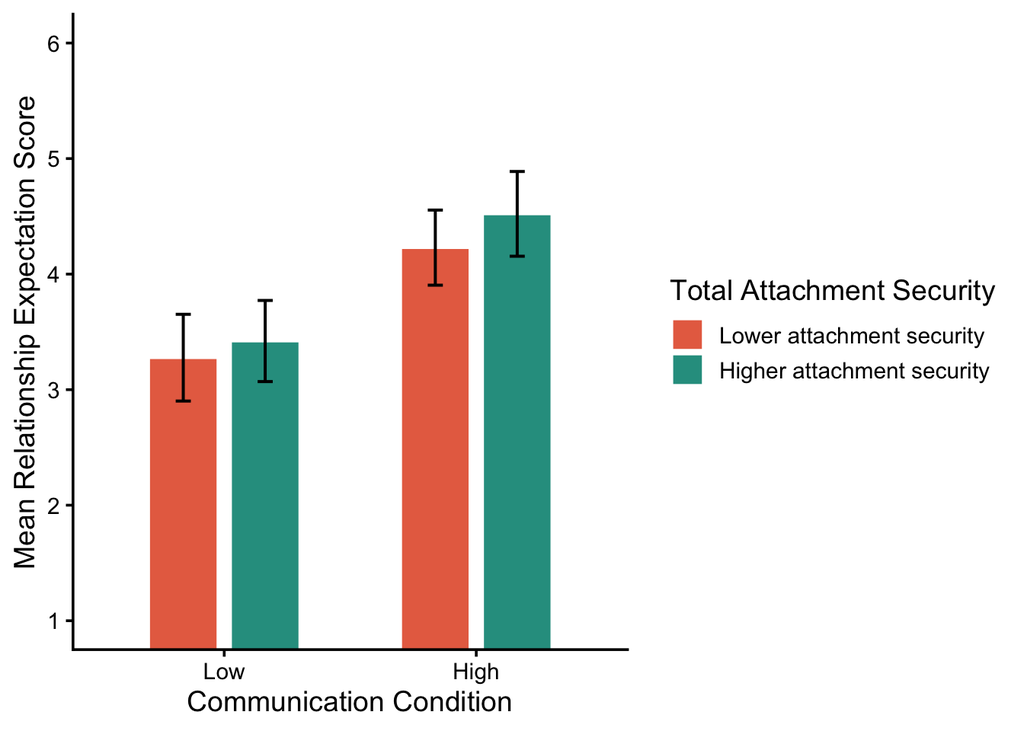

```r
p_ETTR_total_bar <- ggplot(
  as.data.frame(emmeans(a1_ETTR_total, ~ condition * aas_total_group)),
  aes(
    x = condition,
    y = emmean,
    fill = aas_total_group
  )
) +
  geom_col(
    position = position_dodge(width = 0.65),
    width = 0.55,
    color = "white"
  ) +
  geom_errorbar(
    aes(
      ymin = lower.CL,
      ymax = upper.CL
    ),
    position = position_dodge(width = 0.65),
    width = 0.12,
    linewidth = 0.7
  ) +
  labs(
    x = "Communication Condition",
    y = "Mean Relationship Expectation Score",
    fill = "Total Attachment Security"
  ) +
  scale_fill_manual(
    values = c(
      "Lower attachment security" = "#E76F51",  # YOU CAN CHANGE THESE TWO HEX VALUES TO MATCH YOUR POSTER!
      "Higher attachment security" = "#2A9D8F"  # YOU CAN CHANGE THESE TWO HEX VALUES TO MATCH YOUR POSTER!
    )
  ) +
  scale_y_continuous(
    breaks = 1:6
  ) +
  coord_cartesian(
    ylim = c(1, 6)
  ) +
  theme_classic(
    base_size = 14
  )

p_ETTR_total_bar
```

The figure shows estimated relationship expectation scores by profile condition and total attachment security group. Error bars represent 95% confidence intervals.

### Relationship Expectation Interaction Plot: Closeness Security

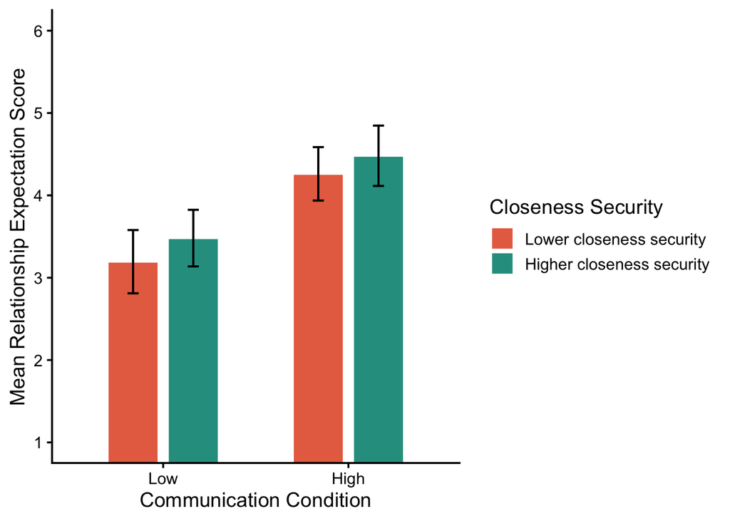

```r
p_ETTR_close_bar <- ggplot(
  as.data.frame(emmeans(a1_ETTR_close, ~ condition * aas_close_group)),
  aes(
    x = condition,
    y = emmean,
    fill = aas_close_group
  )
) +
  geom_col(
    position = position_dodge(width = 0.65),
    width = 0.55,
    color = "white"
  ) +
  geom_errorbar(
    aes(
      ymin = lower.CL,
      ymax = upper.CL
    ),
    position = position_dodge(width = 0.65),
    width = 0.12,
    linewidth = 0.7
  ) +
  labs(
    x = "Communication Condition",
    y = "Mean Relationship Expectation Score",
    fill = "Closeness Security"
  ) +
  scale_fill_manual(
    values = c(
      "Lower closeness security" = "#E76F51",  # YOU CAN CHANGE THESE TWO HEX VALUES TO MATCH YOUR POSTER!
      "Higher closeness security" = "#2A9D8F"  # YOU CAN CHANGE THESE TWO HEX VALUES TO MATCH YOUR POSTER!
    )
  ) +
  scale_y_continuous(
    breaks = 1:6
  ) +
  coord_cartesian(
    ylim = c(1, 6)
  ) +
  theme_classic(
    base_size = 14
  )

p_ETTR_close_bar
```

The figure shows estimated relationship expectation scores by profile condition and closeness security group. Error bars represent 95% confidence intervals.

### Relationship Expectation Interaction Plot: Dependence Security

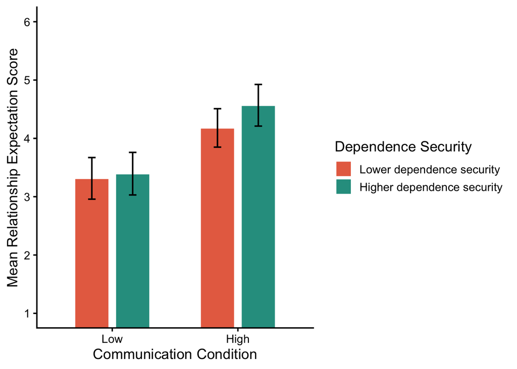

```r
p_ETTR_depend_bar <- ggplot(
  as.data.frame(emmeans(a1_ETTR_depend, ~ condition * aas_depend_group)),
  aes(
    x = condition,
    y = emmean,
    fill = aas_depend_group
  )
) +
  geom_col(
    position = position_dodge(width = 0.65),
    width = 0.55,
    color = "white"
  ) +
  geom_errorbar(
    aes(
      ymin = lower.CL,
      ymax = upper.CL
    ),
    position = position_dodge(width = 0.65),
    width = 0.12,
    linewidth = 0.7
  ) +
  labs(
    x = "Communication Condition",
    y = "Mean Relationship Expectation Score",
    fill = "Dependence Security"
  ) +
  scale_fill_manual(
    values = c(
      "Lower dependence security" = "#E76F51",  # YOU CAN CHANGE THESE TWO HEX VALUES TO MATCH YOUR POSTER!
      "Higher dependence security" = "#2A9D8F"  # YOU CAN CHANGE THESE TWO HEX VALUES TO MATCH YOUR POSTER!
    )
  ) +
  scale_y_continuous(
    breaks = 1:6
  ) +
  coord_cartesian(
    ylim = c(1, 6)
  ) +
  theme_classic(
    base_size = 14
  )

p_ETTR_depend_bar
```

The figure shows estimated relationship expectation scores by profile condition and dependence security group. Error bars represent 95% confidence intervals.

### Relationship Expectation Interaction Plot: Anxiety Security

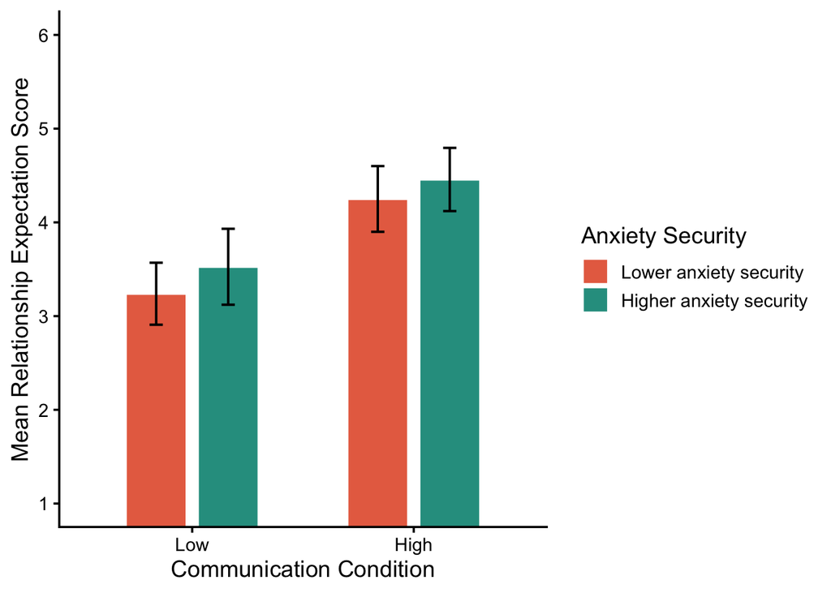

```r
p_ETTR_anxiety_bar <- ggplot(
  as.data.frame(emmeans(a1_ETTR_anxiety, ~ condition * aas_anxiety_group)),
  aes(
    x = condition,
    y = emmean,
    fill = aas_anxiety_group
  )
) +
  geom_col(
    position = position_dodge(width = 0.65),
    width = 0.55,
    color = "white"
  ) +
  geom_errorbar(
    aes(
      ymin = lower.CL,
      ymax = upper.CL
    ),
    position = position_dodge(width = 0.65),
    width = 0.12,
    linewidth = 0.7
  ) +
  labs(
    x = "Communication Condition",
    y = "Mean Relationship Expectation Score",
    fill = "Anxiety Security"
  ) +
  scale_fill_manual(
    values = c(
      "Lower anxiety security" = "#E76F51",  # YOU CAN CHANGE THESE TWO HEX VALUES TO MATCH YOUR POSTER!
      "Higher anxiety security" = "#2A9D8F"  # YOU CAN CHANGE THESE TWO HEX VALUES TO MATCH YOUR POSTER!
    )
  ) +
  scale_y_continuous(
    breaks = 1:6
  ) +
  coord_cartesian(
    ylim = c(1, 6)
  ) +
  theme_classic(
    base_size = 14
  )

p_ETTR_anxiety_bar
```

The figure shows estimated relationship expectation scores by profile condition and anxiety security group. Error bars represent 95% confidence intervals.

### Social Attraction Interaction Plot: Total Attachment Security

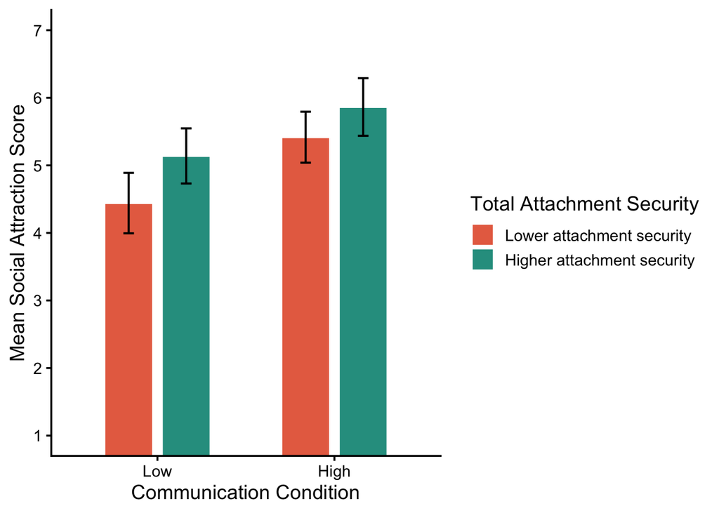

```r
p_IAS_total_bar <- ggplot(
  as.data.frame(emmeans(a1_IAS_total, ~ condition * aas_total_group)),
  aes(
    x = condition,
    y = emmean,
    fill = aas_total_group
  )
) +
  geom_col(
    position = position_dodge(width = 0.65),
    width = 0.55,
    color = "white"
  ) +
  geom_errorbar(
    aes(
      ymin = lower.CL,
      ymax = upper.CL
    ),
    position = position_dodge(width = 0.65),
    width = 0.12,
    linewidth = 0.7
  ) +
  labs(
    x = "Communication Condition",
    y = "Mean Social Attraction Score",
    fill = "Total Attachment Security"
  ) +
  scale_fill_manual(
    values = c(
      "Lower attachment security" = "#E76F51",  # YOU CAN CHANGE THESE TWO HEX VALUES TO MATCH YOUR POSTER!
      "Higher attachment security" = "#2A9D8F"  # YOU CAN CHANGE THESE TWO HEX VALUES TO MATCH YOUR POSTER!
    )
  ) +
  scale_y_continuous(
    breaks = 1:7
  ) +
  coord_cartesian(
    ylim = c(1, 7)
  ) +
  theme_classic(
    base_size = 14
  )

p_IAS_total_bar
```

The figure shows estimated social attraction scores by profile condition and total attachment security group. Error bars represent 95% confidence intervals.

### Social Attraction Interaction Plot: Closeness Security

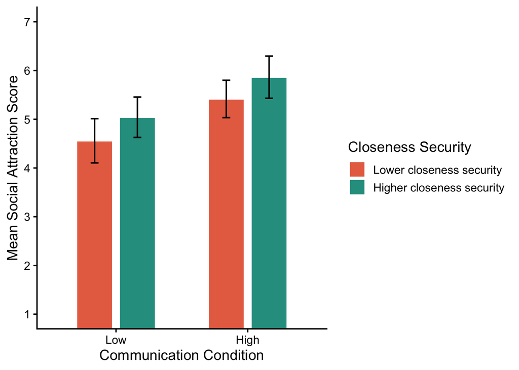

```r
p_IAS_close_bar <- ggplot(
  as.data.frame(emmeans(a1_IAS_close, ~ condition * aas_close_group)),
  aes(
    x = condition,
    y = emmean,
    fill = aas_close_group
  )
) +
  geom_col(
    position = position_dodge(width = 0.65),
    width = 0.55,
    color = "white"
  ) +
  geom_errorbar(
    aes(
      ymin = lower.CL,
      ymax = upper.CL
    ),
    position = position_dodge(width = 0.65),
    width = 0.12,
    linewidth = 0.7
  ) +
  labs(
    x = "Communication Condition",
    y = "Mean Social Attraction Score",
    fill = "Closeness Security"
  ) +
  scale_fill_manual(
    values = c(
      "Lower closeness security" = "#E76F51",  # YOU CAN CHANGE THESE TWO HEX VALUES TO MATCH YOUR POSTER!
      "Higher closeness security" = "#2A9D8F"  # YOU CAN CHANGE THESE TWO HEX VALUES TO MATCH YOUR POSTER!
    )
  ) +
  scale_y_continuous(
    breaks = 1:7
  ) +
  coord_cartesian(
    ylim = c(1, 7)
  ) +
  theme_classic(
    base_size = 14
  )

p_IAS_close_bar
```

The figure shows estimated social attraction scores by profile condition and closeness security group. Error bars represent 95% confidence intervals.

### Social Attraction Interaction Plot: Dependence Security

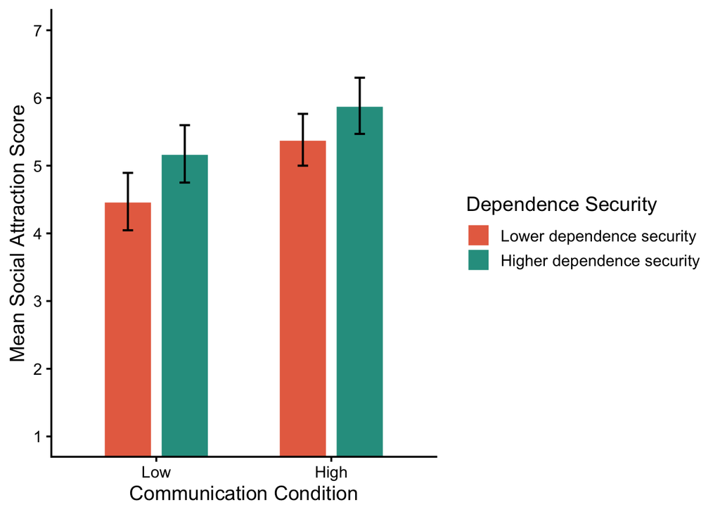

```r
p_IAS_depend_bar <- ggplot(
  as.data.frame(emmeans(a1_IAS_depend, ~ condition * aas_depend_group)),
  aes(
    x = condition,
    y = emmean,
    fill = aas_depend_group
  )
) +
  geom_col(
    position = position_dodge(width = 0.65),
    width = 0.55,
    color = "white"
  ) +
  geom_errorbar(
    aes(
      ymin = lower.CL,
      ymax = upper.CL
    ),
    position = position_dodge(width = 0.65),
    width = 0.12,
    linewidth = 0.7
  ) +
  labs(
    x = "Communication Condition",
    y = "Mean Social Attraction Score",
    fill = "Dependence Security"
  ) +
  scale_fill_manual(
    values = c(
      "Lower dependence security" = "#E76F51",  # YOU CAN CHANGE THESE TWO HEX VALUES TO MATCH YOUR POSTER!
      "Higher dependence security" = "#2A9D8F"  # YOU CAN CHANGE THESE TWO HEX VALUES TO MATCH YOUR POSTER!
    )
  ) +
  scale_y_continuous(
    breaks = 1:7
  ) +
  coord_cartesian(
    ylim = c(1, 7)
  ) +
  theme_classic(
    base_size = 14
  )

p_IAS_depend_bar
```

The figure shows estimated social attraction scores by profile condition and dependence security group. Error bars represent 95% confidence intervals.

### Social Attraction Interaction Plot: Anxiety Security

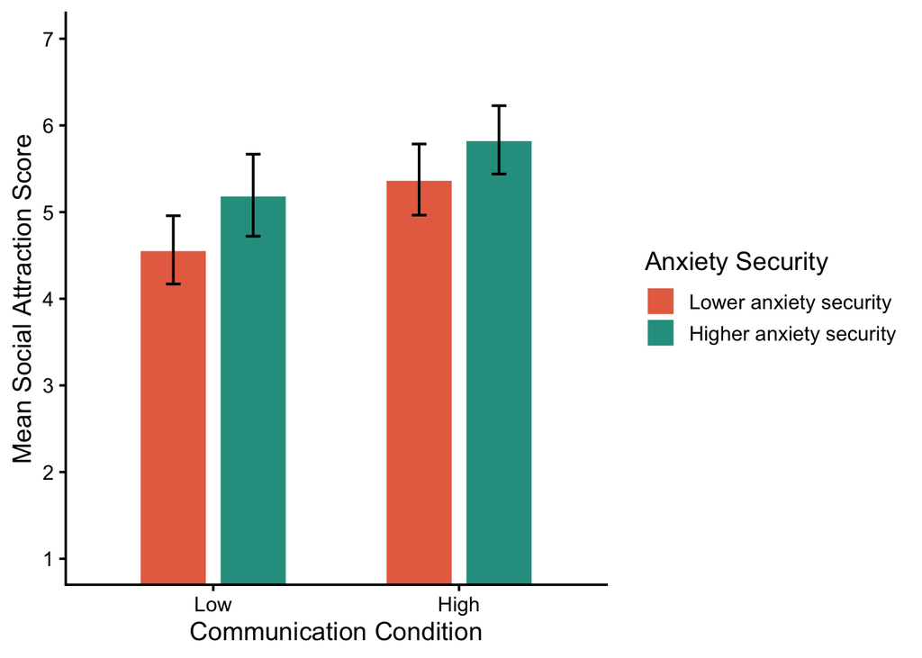

```r
p_IAS_anxiety_bar <- ggplot(
  as.data.frame(emmeans(a1_IAS_anxiety, ~ condition * aas_anxiety_group)),
  aes(
    x = condition,
    y = emmean,
    fill = aas_anxiety_group
  )
) +
  geom_col(
    position = position_dodge(width = 0.65),
    width = 0.55,
    color = "white"
  ) +
  geom_errorbar(
    aes(
      ymin = lower.CL,
      ymax = upper.CL
    ),
    position = position_dodge(width = 0.65),
    width = 0.12,
    linewidth = 0.7
  ) +
  labs(
    x = "Communication Condition",
    y = "Mean Social Attraction Score",
    fill = "Anxiety Security"
  ) +
  scale_fill_manual(
    values = c(
      "Lower anxiety security" = "#E76F51",  # YOU CAN CHANGE THESE TWO HEX VALUES TO MATCH YOUR POSTER!
      "Higher anxiety security" = "#2A9D8F"  # YOU CAN CHANGE THESE TWO HEX VALUES TO MATCH YOUR POSTER!
    )
  ) +
  scale_y_continuous(
    breaks = 1:7
  ) +
  coord_cartesian(
    ylim = c(1, 7)
  ) +
  theme_classic(
    base_size = 14
  )

p_IAS_anxiety_bar
```

The figure shows estimated social attraction scores by profile condition and anxiety security group. Error bars represent 95% confidence intervals.

### Save FIgures

```r
if (!dir.exists("figures")) {
  dir.create("figures")
}

ggsave(
  filename = "figures/relationship_expectation_total_attachment_security_interaction_plot.svg",
  plot = p_ETTR_total_bar,
  width = 7,
  height = 5
)

ggsave(
  filename = "figures/relationship_expectation_closeness_security_interaction_plot.svg",
  plot = p_ETTR_close_bar,
  width = 7,
  height = 5
)

ggsave(
  filename = "figures/relationship_expectation_dependence_security_interaction_plot.svg",
  plot = p_ETTR_depend_bar,
  width = 7,
  height = 5
)

ggsave(
  filename = "figures/relationship_expectation_anxiety_security_interaction_plot.svg",
  plot = p_ETTR_anxiety_bar,
  width = 7,
  height = 5
)

ggsave(
  filename = "figures/social_attraction_total_attachment_security_interaction_plot.svg",
  plot = p_IAS_total_bar,
  width = 7,
  height = 5
)

ggsave(
  filename = "figures/social_attraction_closeness_security_interaction_plot.svg",
  plot = p_IAS_close_bar,
  width = 7,
  height = 5
)

ggsave(
  filename = "figures/social_attraction_dependence_security_interaction_plot.svg",
  plot = p_IAS_depend_bar,
  width = 7,
  height = 5
)

ggsave(
  filename = "figures/social_attraction_anxiety_security_interaction_plot.svg",
  plot = p_IAS_anxiety_bar,
  width = 7,
  height = 5
)
```

## Results Summary

The primary analyses tested whether profile condition, attachment security group, and their interaction predicted relationship expectation and social attraction scores. Across the ANOVA models, profile condition was the most consistent statistically significant predictor. Participants exposed to the high-condition profile generally reported higher relationship expectation and social attraction scores than participants exposed to the low-condition profile.